# R Notebook

github: https://github.com/MatthewPr12/SpotTheDifference

Our team decided to analyze how top music charts changed 10 months before the full scale invasions, after it and up until now.  
The data was taken from the audio and media streaming service “Spotify”. It consists of top-200 songs of every week from April of 2021 till December of 2022

The idea is to analyze to which nation the artist belongs and based on this information test how trends changed. ### Reading data

```r
weekly_by_streams = read.csv("joined_by_streams/joined_by_streams.csv")[,-1]
head(weekly_by_streams)
```

|  | EN | RU | UA | week |
| --- | --- | --- | --- | --- |
| 1 | 1904102 | 3441525 | 153478 | 2021-04-29 |
| 2 | 1849496 | 3807013 | 134312 | 2021-05-06 |
| 3 | 1894245 | 3759507 | 114788 | 2021-05-13 |
| 4 | 1795745 | 4382919 | 115415 | 2021-05-20 |
| 5 | 2635710 | 4964155 | 407745 | 2021-05-27 |
| 6 | 2838894 | 5426174 | 340332 | 2021-06-03 |

```r
weekly_by_quantity = read.csv("joined_by_quantity/joined_by_quantity.csv")[,-1]
head(weekly_by_quantity)
```

|  | EN | RU | UA | week |
| --- | --- | --- | --- | --- |
| 1 | 71 | 121 | 8 | 2021-04-29 |
| 2 | 67 | 127 | 6 | 2021-05-06 |
| 3 | 69 | 126 | 5 | 2021-05-13 |
| 4 | 64 | 131 | 5 | 2021-05-20 |
| 5 | 69 | 121 | 10 | 2021-05-27 |
| 6 | 68 | 123 | 9 | 2021-06-03 |

```r
weekly_by_streams_perc = read.csv("joined_by_streams/joined_by_streams_perc.csv")[,-1]
head(weekly_by_streams_perc)
```

|  | EN | RU | UA | week |
| --- | --- | --- | --- | --- |
| 1 | 34.62567 | 62.58337 | 2.790963 | 2021-04-29 |
| 2 | 31.93841 | 65.74220 | 2.319395 | 2021-05-06 |
| 3 | 32.83751 | 65.17259 | 1.989897 | 2021-05-13 |
| 4 | 28.53070 | 69.63559 | 1.833708 | 2021-05-20 |
| 5 | 32.91506 | 61.99297 | 5.091969 | 2021-05-27 |
| 6 | 32.98968 | 63.05545 | 3.954866 | 2021-06-03 |

### Plot the data

```r
library(ggplot2)
library(reshape2)

plot_lang <- function(df, title){
  df <- melt(df , id.vars = 'week', variable.name = 'lang')
  ggplot(df, aes(week, value, group=lang)) +
  scale_x_discrete(guide = guide_axis(check.overlap=TRUE))+
  theme(axis.text.x = element_text(angle = 90)) +
  geom_point(aes(colour = lang)) + geom_line(aes(colour=lang)) +
    labs(title = title) +
         geom_vline(xintercept=44,
                linetype=4, colour="black")
}
```

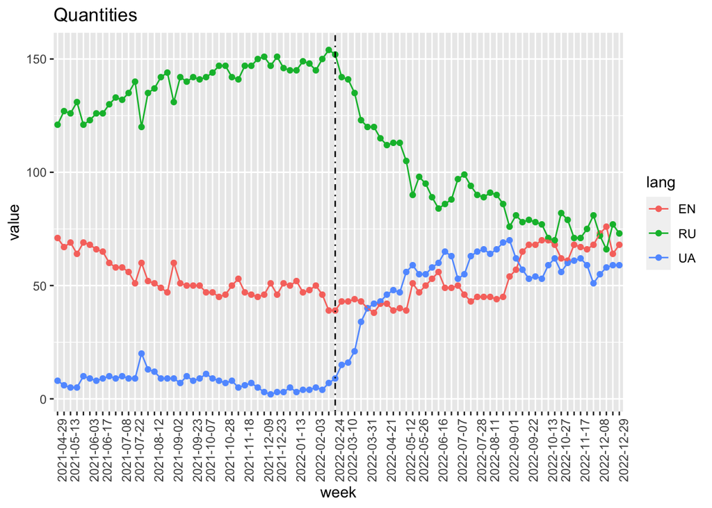

```r
plot_lang(weekly_by_quantity, "Quantities")
```

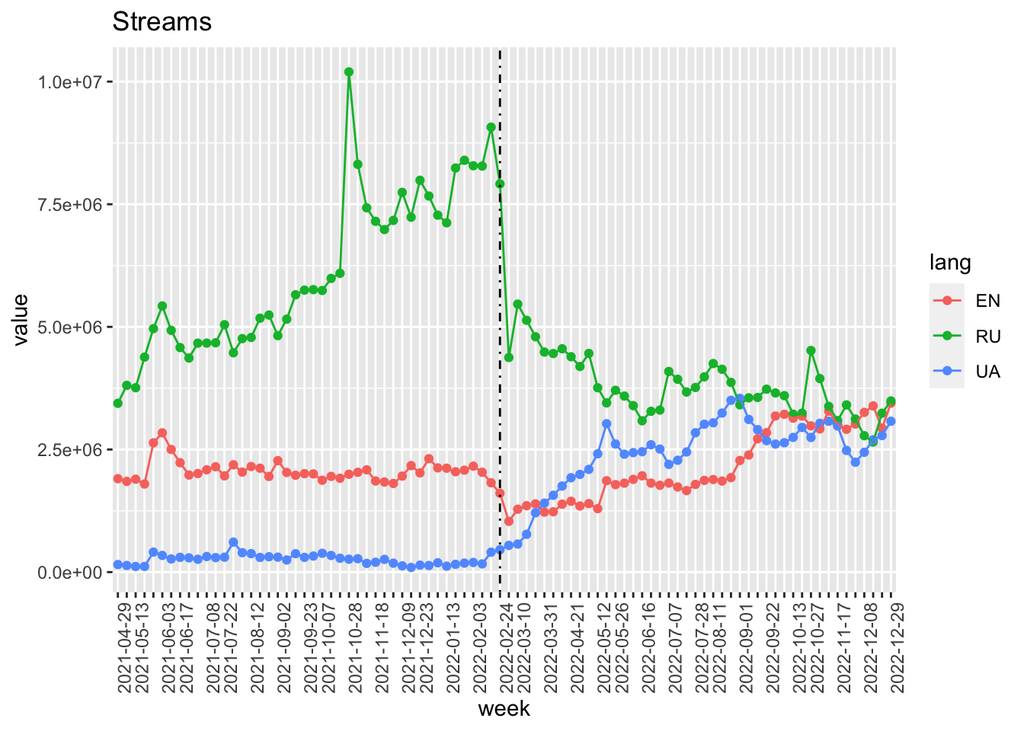

```r
plot_lang(weekly_by_streams, "Streams")
```

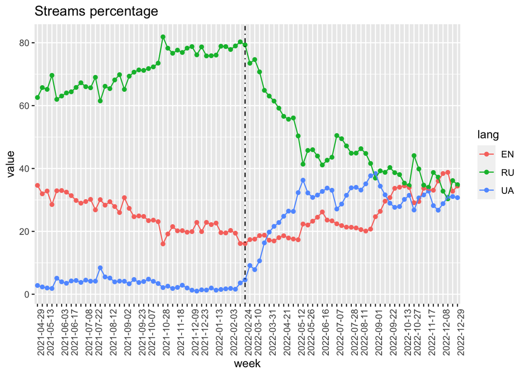

```r
plot_lang(weekly_by_streams_perc, "Streams percentage")
```

## Compare average time before the full-scale invasion and after

### Split the data

```r
quant_before = subset(weekly_by_quantity, week < "2022-02-24")
quant_after = subset(weekly_by_quantity, week >= "2022-02-24")

streams_before = subset(weekly_by_streams, week < "2022-02-24")
streams_after = subset(weekly_by_streams, week >= "2022-02-24")
```

We include **24.02.2022** into subset of those charts after the full-scale invasion because it started nearly 4:00 am, therefore, we suppose that Ukrainians did not listen that much music from 00:00 till 04:00

```r
UA_quant_before = quant_before["UA"]
EN_quant_before = quant_before["EN"]
RU_quant_before = quant_before["RU"]

UA_quant_after = quant_after["UA"]
EN_quant_after = quant_after["EN"]
RU_quant_after = quant_after["RU"]

UA_streams_before = streams_before["UA"]
EN_streams_before = streams_before["EN"]
RU_streams_before = streams_before["RU"]

UA_streams_after = streams_after["UA"]
EN_streams_after = streams_after["EN"]
RU_streams_after = streams_after["RU"]
```

#### UA

##### Num in top-200

Since it is quite obvious, that Ukrainians started listening to Ukrainian music much more often, our hypothesis will look the following:
$$H_0:\ \mu_0 = \mu_1$$
where $\mu_0$ is the average number of Ukrainian songs in top-200 every week before the full-scale invasion. $\mu_1$ is the average number of Ukrainian songs in top-200 every week after the full-scale invasion.
$$H_1:\ \mu_0 \lt \mu_1$$

We use t-test to compare two populations’ means. We make somewhat strong assumption that two populations are independent. We do so, as it is obvious that the music tastes of Ukrainians significantly changed after 24.02.2022.

Now we also suppose that variances of two populations are unequal and unknown

$$t = \frac{(\bar{x_0} - \bar{x_1}) -
(\mu_0 - \mu_1)}{\sqrt{\frac{s_0^2}{n_0} +
\frac{s_1^2}{n_1}}}$$

```r
t.test(as.numeric(unlist(UA_quant_before)), as.numeric(unlist(UA_quant_after)), mu=0, alt="less", conf.int = T, conf.level = 0.95)
```

```
##
##  Welch Two Sample t-test
##
## data:  as.numeric(unlist(UA_quant_before)) and as.numeric(unlist(UA_quant_after))
## t = -20.958, df = 48.996, p-value < 2.2e-16
## alternative hypothesis: true difference in means is less than 0
## 95 percent confidence interval:
##       -Inf -41.82999
## sample estimates:
## mean of x mean of y
##  7.488372 52.955556
```

##### Streams

Now we perform the same tests but for number of streams of Ukrainian songs (number of times Ukrainian songs have been chosen)

```r
t.test(as.numeric(unlist(UA_streams_before)), as.numeric(unlist(UA_streams_after)), mu=0, alt="less", conf.int = T, conf.level = 0.95)
```

```
##
##  Welch Two Sample t-test
##
## data:  as.numeric(unlist(UA_streams_before)) and as.numeric(unlist(UA_streams_after))
## t = -18.724, df = 45.807, p-value < 2.2e-16
## alternative hypothesis: true difference in means is less than 0
## 95 percent confidence interval:
##      -Inf -1949890
## sample estimates:
## mean of x mean of y
##  259069.4 2401009.8
```

Results are pretty much the same. Number of times Ukrainian turned Ukrainian songs from top-200 on average increased by 10 times

#### EN

##### Num in top-200

For the number of English songs in top-200 Ukrainian charts it is not that obvious about how the tastes changed. So we will perform two-sided t-test, as our $H_0:\ \mu_0=\mu_1$ and $H_1:\ \mu_0 \neq \mu_1$
$$T = \frac{\bar{x_0} -
\bar{x_1}}{\sqrt{\frac{s_0^2}{n_0} + \frac{s_1^2}{n_1}}}$$
Then, we will reject our $H_0$ if $|T|\gt t_{1-\alpha/2, \nu}$ where $\nu$ represents degrees of freedom

```r
t.test(as.numeric(unlist(EN_quant_before)), as.numeric(unlist(EN_quant_after)), conf.int = T, conf.level = 0.95)
```

```
##
##  Welch Two Sample t-test
##
## data:  as.numeric(unlist(EN_quant_before)) and as.numeric(unlist(EN_quant_after))
## t = -0.023965, df = 78.604, p-value = 0.9809
## alternative hypothesis: true difference in means is not equal to 0
## 95 percent confidence interval:
##  -4.300867  4.198542
## sample estimates:
## mean of x mean of y
##  53.34884  53.40000
```

As we can see from the results of the t-test, p-value is much bigger than 0.05($\alpha$) so we do not reject the $H_0$. In other words, we cannot conclude that significant difference exists.

So the number of not Ukrainian and not russian songs in Ukrainian top-200 did not change much

##### Streams

Now we perform the same test for the number of times Ukrainians turned English songs from top-200

```r
t.test(as.numeric(unlist(EN_streams_before)), as.numeric(unlist(EN_streams_after)), conf.int = T, conf.level = 0.95)
```

```
##
##  Welch Two Sample t-test
##
## data:  as.numeric(unlist(EN_streams_before)) and as.numeric(unlist(EN_streams_after))
## t = -0.88336, df = 51.157, p-value = 0.3812
## alternative hypothesis: true difference in means is not equal to 0
## 95 percent confidence interval:
##  -335598.3  130496.3
## sample estimates:
## mean of x mean of y
##   2064483   2167034
```

P-value is now smaller, but still more than $0.05$ so we do not reject $H_0$ about the equality of the average number of English songs replays in top-200

#### RU

###### Num in top-200

Numbers of russian songs in Ukrainian top-200 charts are rather scary. They changed to the smaller ones after the full-scale invasion(Hurray, what a surprise), but not that much.

The test statistic can be calculated:

$$t = \frac{(\bar{x_0} - \bar{x_1}) -
(\mu_0 - \mu_1)}{\sqrt{\frac{s_0^2}{n_0} +
\frac{s_1^2}{n_1}}}$$

```r
t.test(as.numeric(unlist(RU_quant_before)), as.numeric(unlist(RU_quant_after)), mu=0, alt="greater", conf.int = T, conf.level = 0.95)
```

```
##
##  Welch Two Sample t-test
##
## data:  as.numeric(unlist(RU_quant_before)) and as.numeric(unlist(RU_quant_after))
## t = 12.939, df = 61.019, p-value < 2.2e-16
## alternative hypothesis: true difference in means is greater than 0
## 95 percent confidence interval:
##  39.62229      Inf
## sample estimates:
## mean of x mean of y
## 139.13953  93.64444
```

Now, we see, that p-value is really small(close to 0), which means, that we should reject our $H_0$ about the equality of means. In other words, with in $\approx 0$ out of $100$ cases samples means will be equal.

And yeah, from the plot and calculated means, we see that the number of russian songs really became less. However, not much. :(

##### Streams

Now, we perform the same test for the number of times, russian songs have been on replay among Ukrainians

```r
t.test(as.numeric(unlist(RU_streams_before)), as.numeric(unlist(RU_streams_after)), mu=0, alt="greater", conf.int = T, conf.level = 0.95)
```

```
##
##  Welch Two Sample t-test
##
## data:  as.numeric(unlist(RU_streams_before)) and as.numeric(unlist(RU_streams_after))
## t = 7.8574, df = 62.45, p-value = 3.344e-11
## alternative hypothesis: true difference in means is greater than 0
## 95 percent confidence interval:
##  1746574     Inf
## sample estimates:
## mean of x mean of y
##   6108093   3890250
```

Results are pretty much the same, number of replays of russian songs from top-200 decreased. We can say so from rejecting $H_0$ about the equality of two means

### Total music change

```r
total_streams_before = UA_streams_before + EN_streams_before + RU_streams_before
total_streams_after = UA_streams_after + EN_streams_after + RU_streams_after
```

We want to test whether after the full-scale invasion, total number of music listened by Ukrainians changed. For that we will use t-test to compare to means - before and after 24.02.2022 respectively

```r
t.test(as.numeric(unlist(total_streams_before)), as.numeric(unlist(total_streams_after)), mu=0, alt="greater", conf.int = T, conf.level = 0.95)
```

```
##
##  Welch Two Sample t-test
##
## data:  as.numeric(unlist(total_streams_before)) and as.numeric(unlist(total_streams_after))
## t = -0.093409, df = 67.703, p-value = 0.5371
## alternative hypothesis: true difference in means is greater than 0
## 95 percent confidence interval:
##  -502408.6       Inf
## sample estimates:
## mean of x mean of y
##   8431645   8458293
```

One can see that $p-value > 0.05$ which means that we fail to reject the $H_0$. Thus, from the top-200 chart it looks as Ukrainian continue to consume nearly the same amount of music, however, the quality of this music improved a little bit

# Distribution of songs’ streams

Splitting the data-frame in 2 parts:

```r
before_war <- weekly_by_streams_perc[row.names(weekly_by_streams_perc) %in% 1:47, ]
after_war <- weekly_by_streams_perc[row.names(weekly_by_streams_perc) %in% 48:nrow(weekly_by_streams_perc), ]
```

Plotting the number of songs’ streams in Top 200:

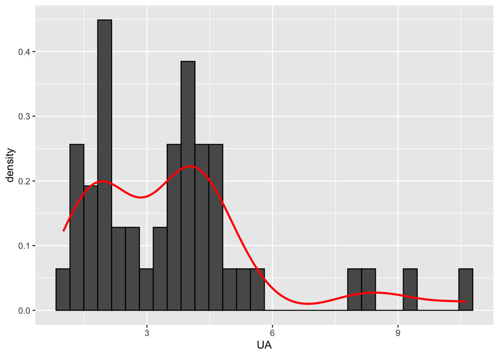

```r
ggplot(before_war[3], aes(x = UA)) +
geom_histogram(col="black", aes(y = after_stat(density))) +
geom_density(col = "red", linewidth=1)
```

By looking at the plot one can assume that Ukrainian songs in Top 200 are normally distributed.

One can check this using the Kolmogorov-Smirnov test since the distribution can be approximated as a continuous one.

$$H_0 - the \ data \ is \ drawn \ from \ a \ normal \ distribution. \\
H_1 - not \ from \ a \ normal \ distribution.$$

```r
ks.test(before_war[3]$UA, "pnorm")
```

```
##
##  Exact one-sample Kolmogorov-Smirnov test
##
## data:  before_war[3]$UA
## D = 0.88088, p-value = 5.551e-16
## alternative hypothesis: two-sided
```

As can be seen, one should reject reject the Null hypothesis, as p-value is tiny.

### Similar for English songs:

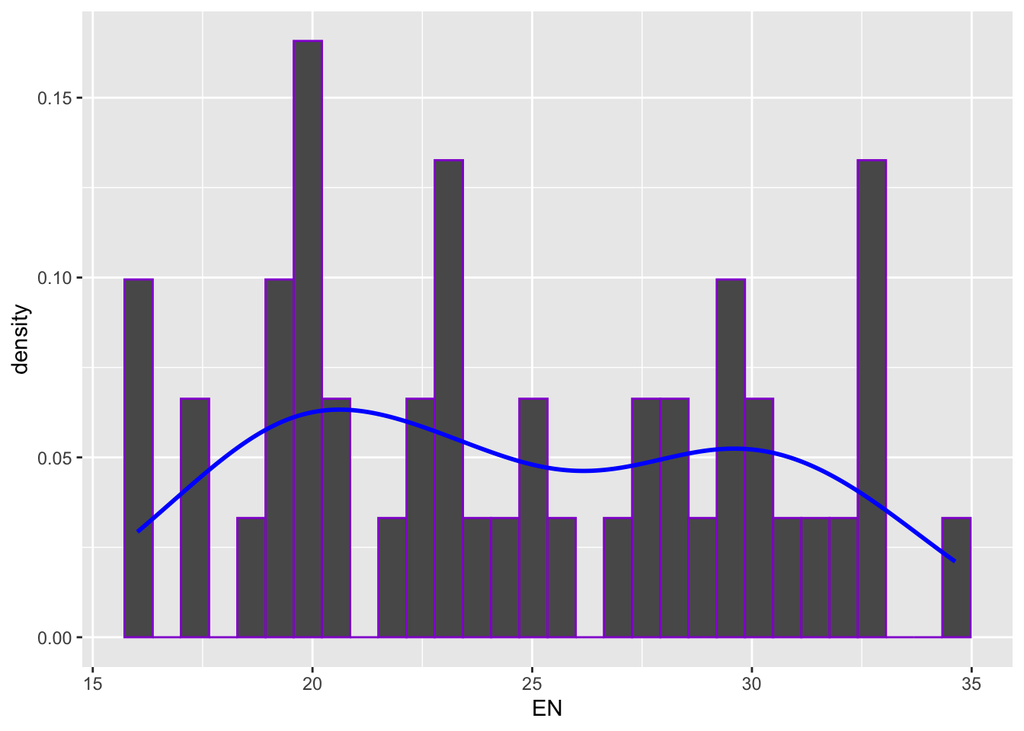

```r
ggplot(before_war[1], aes(x = EN)) +
geom_histogram(colour="darkviolet", aes(y = after_stat(density)) ) +
geom_density(col = "blue", linewidth=1)
```

Let’s take a look at the empirical CDF:

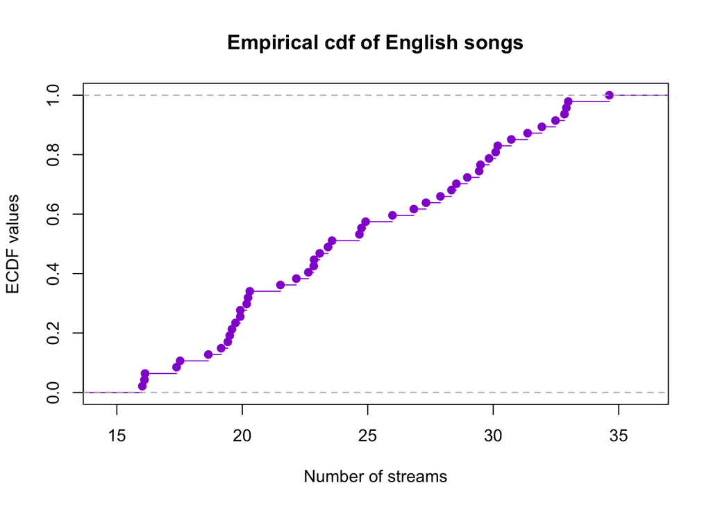

```r
plot(ecdf(before_war[1]$EN), ylab="ECDF values", xlab="Number of streams", main="Empirical cdf of English songs", col="darkviolet")
```

It does not look like any sane distribution, but let’s check it for being the uniform:

```r
ks.test(before_war[1]$EN, "punif")
```

```
##
##  Exact one-sample Kolmogorov-Smirnov test
##
## data:  before_war[1]$EN
## D = 1, p-value = 5.551e-16
## alternative hypothesis: two-sided
```

It is also not a uniform distribution.

```r
x <- seq(1, 47, by=1)

test_linear <- function(y, col1, col2) {
  linearmodel <- lm(y ~ x)
  plot(x, y, pch=1, col = col1)
  abline(linearmodel, col = col2)
  summary(linearmodel)
}
```

### Test for Ukrainian songs:

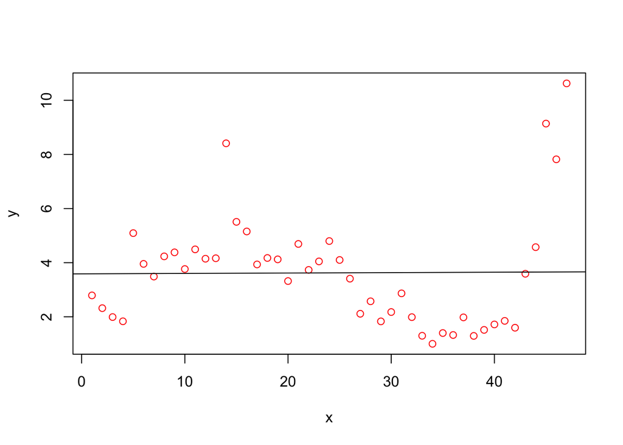

```
##
## Call:
## lm(formula = y ~ x)
##
## Residuals:
##     Min      1Q  Median      3Q     Max
## -2.6367 -1.6566 -0.0622  0.7066  6.9661
##
## Coefficients:
##             Estimate Std. Error t value Pr(>|t|)
## (Intercept) 3.587655   0.626833   5.723 8.02e-07 ***
## x           0.001506   0.022738   0.066    0.947
## ---
## Signif. codes:  0 '***' 0.001 '**' 0.01 '*' 0.05 '.' 0.1 ' ' 1
##
## Residual standard error: 2.114 on 45 degrees of freedom
## Multiple R-squared:  9.744e-05,  Adjusted R-squared:  -0.02212
## F-statistic: 0.004385 on 1 and 45 DF,  p-value: 0.9475
```

```r
test_linear(before_war[3]$UA, "red", "black")
```

From the plot it is clear that linear model is terrible.

### Test for English songs

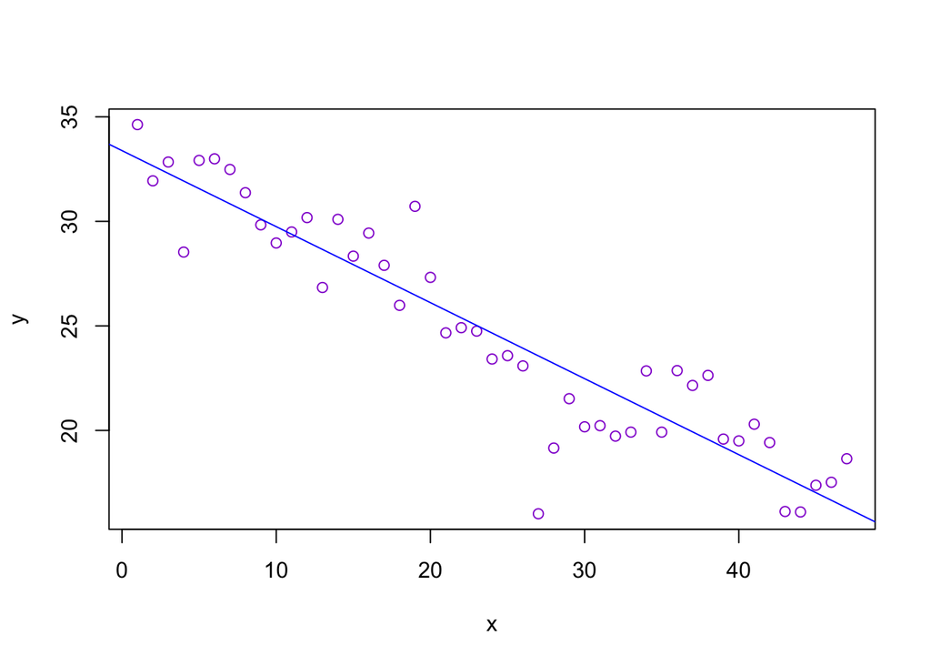

```
##
## Call:
## lm(formula = y ~ x)
##
## Residuals:
##     Min      1Q  Median      3Q     Max
## -7.5524 -1.1625  0.3546  1.4783  4.2428
##
## Coefficients:
##             Estimate Std. Error t value Pr(>|t|)
## (Intercept) 33.38264    0.61232   54.52   <2e-16 ***
## x           -0.36352    0.02221  -16.37   <2e-16 ***
## ---
## Signif. codes:  0 '***' 0.001 '**' 0.01 '*' 0.05 '.' 0.1 ' ' 1
##
## Residual standard error: 2.066 on 45 degrees of freedom
## Multiple R-squared:  0.8562, Adjusted R-squared:  0.853
## F-statistic: 267.9 on 1 and 45 DF,  p-value: < 2.2e-16
```

```r
test_linear(before_war[1]$EN, "darkviolet", "blue")
```

### Test for russian songs:

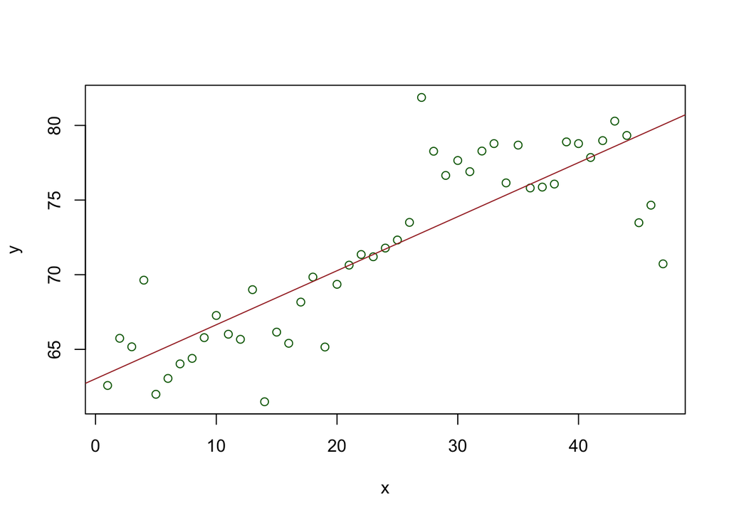

```
##
## Call:
## lm(formula = y ~ x)
##
## Residuals:
##     Min      1Q  Median      3Q     Max
## -9.3163 -1.2720  0.0679  1.4811  9.0684
##
## Coefficients:
##             Estimate Std. Error t value Pr(>|t|)
## (Intercept) 63.02970    0.96232   65.50  < 2e-16 ***
## x            0.36201    0.03491   10.37 1.64e-13 ***
## ---
## Signif. codes:  0 '***' 0.001 '**' 0.01 '*' 0.05 '.' 0.1 ' ' 1
##
## Residual standard error: 3.246 on 45 degrees of freedom
## Multiple R-squared:  0.705,  Adjusted R-squared:  0.6985
## F-statistic: 107.6 on 1 and 45 DF,  p-value: 1.642e-13
```

```r
test_linear(before_war[2]$RU, "darkgreen", "brown")
```

As can be seen, only russian and English songs’ streams can be estimated using the linear regression model, since for them the determination coefficient is larger than 0.7.

This shows it does not always make sense to try to approximate the data by some distribution, since in this case people’s taste in music vary under different circumstances that are not taken into account. This explains why the distribution look so strange on the plots.

Applying the linear regression model may help approximate the future statistics, but only if the environment remains approximately the same. It did not.

# Data after 24.02 analysis

## russian songs

As we can see from the plots, the percentage streams of russian songs decreases in time and it’s plot looks like exponential/logarithmic. So we applied linear regression model with rescaled parameters, and assumed that
$$Y = a + b \cdot ln(X)$$
Where our $Y-$ the percentage of total streams from russian songs. $X-$ weeks after full-scale invasion.

```r
perc_after_RU <- weekly_by_streams_perc$RU[weekly_by_streams_perc$week > "2022-02-24"]
ru.Streams.Percentage <- (perc_after_RU)
X_streams_perc_ru <- (c(1:length(perc_after_RU)))
Y_weeks_ru <- (perc_after_RU)
ru_lmodel = lm(Y_weeks_ru ~ log(X_streams_perc_ru))
summary(ru_lmodel)
```

```
##
## Call:
## lm(formula = Y_weeks_ru ~ log(X_streams_perc_ru))
##
## Residuals:
##     Min      1Q  Median      3Q     Max
## -9.0220 -2.6239  0.7366  2.5697  6.6024
##
## Coefficients:
##                        Estimate Std. Error t value Pr(>|t|)
## (Intercept)             80.3231     1.8114   44.34   <2e-16 ***
## log(X_streams_perc_ru) -12.0446     0.6082  -19.80   <2e-16 ***
## ---
## Signif. codes:  0 '***' 0.001 '**' 0.01 '*' 0.05 '.' 0.1 ' ' 1
##
## Residual standard error: 3.511 on 42 degrees of freedom
## Multiple R-squared:  0.9033, Adjusted R-squared:  0.901
## F-statistic: 392.2 on 1 and 42 DF,  p-value: < 2.2e-16
```

As we can see from the results: 1. R-squared value: $r^2 \approx 0.90$ so we our assumption is good enough and it precisely describes the relation. 2. p-values for Null Hypotheses of $a=0$ and $b=0$ are close to zero, so we reject them and take:
$$a \approx 80.32 \\
b \approx -12.05 \\
Y = 80.32 -12.05\cdot ln(X)$$

Having plotted the actual data and the theoretical line, we can obviously see the tendency to decreasing in russian songs’ streams; and that is great.

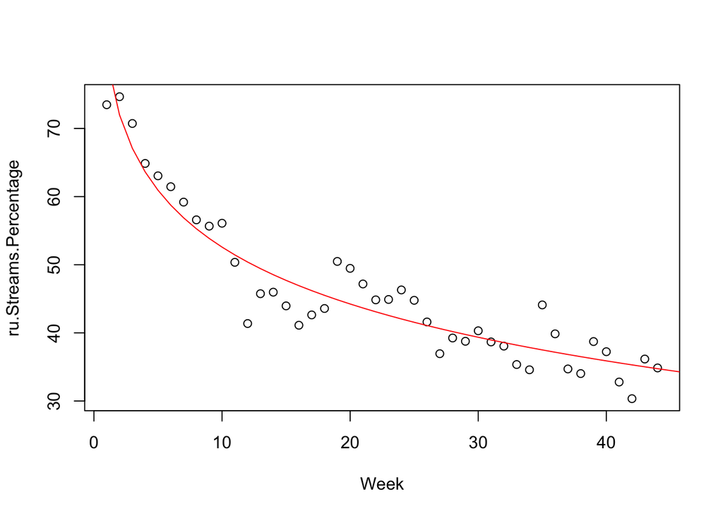

```r
plot(ru.Streams.Percentage, xlab='Week')
x_val <- c(1:50)
line <- (log(x_val)*ru_lmodel$coefficients[2] + ru_lmodel$coefficients[1])
lines(x_val, line, col='red')
```

## Ukrainian songs

To fit it into linear regression model we have to take $log(Y) \sim log(X)$:
$$log(Y) = a + b\cdot log(X)$$
That will give us that:
$$exp(log(Y)) = exp(a+b\cdot log(X))\\
Y = exp(a) \cdot X^b\\
Y = c*X^b$$

```r
perc_after_UA <- weekly_by_streams$UA[weekly_by_streams_perc$week > "2022-02-24"]
UA.Streams.Number <- perc_after_UA
X_Streams_ua <- (c(1:length(perc_after_UA)))
Y_weeks_ua <- (perc_after_UA)
ua_lmodel = lm(log(Y_weeks_ua) ~ log(X_Streams_ua))
summary(ua_lmodel)
```

```
##
## Call:
## lm(formula = log(Y_weeks_ua) ~ log(X_Streams_ua))
##
## Residuals:
##      Min       1Q   Median       3Q      Max
## -0.46361 -0.10903  0.00185  0.13868  0.43436
##
## Coefficients:
##                   Estimate Std. Error t value Pr(>|t|)
## (Intercept)       13.42408    0.09930  135.19  < 2e-16 ***
## log(X_Streams_ua)  0.42820    0.03334   12.84 3.89e-16 ***
## ---
## Signif. codes:  0 '***' 0.001 '**' 0.01 '*' 0.05 '.' 0.1 ' ' 1
##
## Residual standard error: 0.1925 on 42 degrees of freedom
## Multiple R-squared:  0.797,  Adjusted R-squared:  0.7922
## F-statistic: 164.9 on 1 and 42 DF,  p-value: 3.893e-16
```

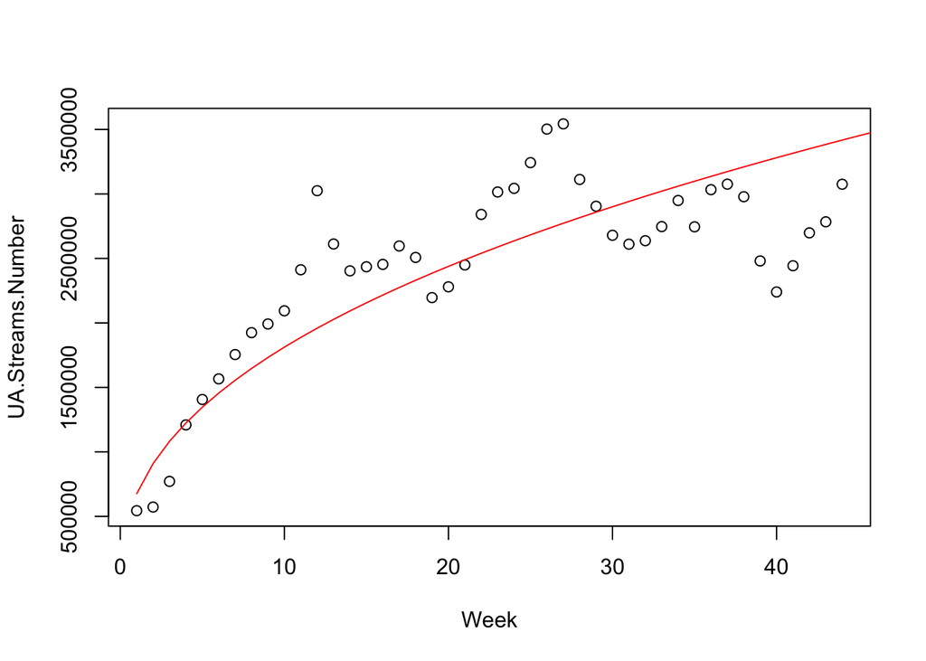

```r
plot(UA.Streams.Number, xlab='Week')
x_val <- c(1:100)
line <- exp(log(x_val)*ua_lmodel$coefficients[2] + ua_lmodel$coefficients[1])
lines(x_val, line, col='red')
```

1. Analyzed hypothesis about the linear growth of replays of russian music among Ukrainians. This turned out to be false. During the full-scale invasion, Ukrainians listen to russian music less and less
2. Still Ukrainians disappoint, as the number of times, russian music reaches top-200 much more frequently than Ukrainian songs
3. Before the full-scale invasion there where numerous weaker factors, that affected top-200 Ukrainian charts. Therefore, it is hard to observe what distribution each language-written songs have. However, after the 24th of February one pretty huge factor occurred, which settled some sort of tendency for the charts
4. Neither light absence nor bombing prevent Ukrainians from listening to their favorite music, so the time, Ukrainians spent in Spotify did not change much.